# R Notebook

```r
library(phyloseq); packageVersion("phyloseq")
```

```
[1] ‘1.30.0’
```

```r
library(tidyverse); packageVersion("tidyverse")
```

```
[1] ‘1.3.0’
```

```r
library(philr); packageVersion("philr")
```

```
[1] ‘1.12.0’
```

```r
library(ape); packageVersion("ape")
```

```
[1] ‘5.4’
```

```r
library(broom); packageVersion("broom")
```

```
[1] ‘0.5.4’
```

```r
data(GlobalPatterns)
```

# From Phylr Docuumentation

## Filter Low Abundance OTUs

```r
GP <-  filter_taxa(GlobalPatterns, function(x) sum(x > 3) > (0.2*length(x)), TRUE)
```

```
Found more than one class "phylo" in cache; using the first, from namespace 'phyloseq'
Also defined by ‘tidytree’
```

```r
GP <-  filter_taxa(GP, function(x) sd(x)/mean(x) > 3.0, TRUE)
```

```
Found more than one class "phylo" in cache; using the first, from namespace 'phyloseq'
Also defined by ‘tidytree’
```

```r
GP <- transform_sample_counts(GP, function(x) x+1)
```

[output not shown]

```r
GP
```

```
phyloseq-class experiment-level object
otu_table()   OTU Table:         [ 1248 taxa and 26 samples ]
sample_data() Sample Data:       [ 26 samples by 7 sample variables ]
tax_table()   Taxonomy Table:    [ 1248 taxa by 7 taxonomic ranks ]
phy_tree()    Phylogenetic Tree: [ 1248 tips and 1247 internal nodes ]
```

## Process Phylogenetic Tree

```r
is.rooted(phy_tree(GP)) # Is the tree Rooted?
```

```
[1] TRUE
```

```r
is.binary.tree(phy_tree(GP)) # All multichotomies resolved?
```

```
[1] TRUE
```

```r
phy_tree(GP) <- makeNodeLabel(phy_tree(GP), method="number", prefix='n')
```

[output not shown]

```r
name.balance(phy_tree(GP), tax_table(GP), 'n1')
```

```
[1] "Kingdom_Archaea/Kingdom_Bacteria"
```

## Investigate Dataset Components

```r
otu.table <- t(otu_table(GP))
tree <- phy_tree(GP)
```

[output not shown]

```r
metadata <- sample_data(GP)
tax <- tax_table(GP)

otu.table[1:2,1:2] # OTU Table
```

```
OTU Table:          [2 taxa and 2 samples]
                     taxa are columns
    540305 108964
CL3      1      1
CC1      1      2
```

```r
tree
```

```
Phylogenetic tree with 1248 tips and 1247 internal nodes.

Tip labels:
    540305, 108964, 175045, 546313, 54107, 71074, ...
Node labels:
    n1, n2, n3, n4, n5, n6, ...

Rooted; includes branch lengths.
```

```r
head(metadata,2) # Metadata
```

```
Sample Data:        [2 samples by 7 sample variables]:
```

|  | X.SampleID | Primer | Final_Barcode | Barcode_truncated_plus_T | Barcode_full_length | SampleType | Description |
| --- | --- | --- | --- | --- | --- | --- | --- |
| CL3 | CL3 | ILBC_01 | AACGCA | TGCGTT | CTAGCGTGCGT | Soil | Calhoun South Carolina Pine soil, pH 4.9 |
| CC1 | CC1 | ILBC_02 | AACTCG | CGAGTT | CATCGACGAGT | Soil | Cedar Creek Minnesota, grassland, pH 6.1 |

```r
head(tax,2) # taxonomy table
```

```
Taxonomy Table:     [2 taxa by 7 taxonomic ranks]:
       Kingdom   Phylum          Class            Order
540305 "Archaea" "Crenarchaeota" "Thaumarchaeota" "Cenarchaeales"
108964 "Archaea" "Crenarchaeota" "Thaumarchaeota" "Cenarchaeales"
       Family           Genus            Species
540305 "Cenarchaeaceae" NA               NA
108964 "Cenarchaeaceae" "Nitrosopumilus" "pIVWA5"
```

## Transform data using PhILR

```r
gp.philr <- philr(otu.table, tree,
                  part.weights='enorm.x.gm.counts',
                  ilr.weights='blw.sqrt')
```

```
Building Sequential Binary Partition from Tree...
Building Contrast Matrix...
Transforming the Data...
Calculating ILR Weights...
```

## Ordination

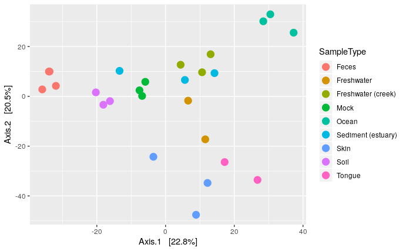

```r
gp.dist <- dist(gp.philr, method="euclidean")
gp.pcoa <- ordinate(GP, 'PCoA', distance=gp.dist)
plot_ordination(GP, gp.pcoa, color='SampleType') + geom_point(size=4)
```

# New Direciton

The authors suggest using glmnet to do a lasoo to identify whihc variables best distinguis humans from non humans

```r
get_variable(GP, "SampleType") %in% c("Feces", "Mock", "Skin", "Tongue")
```

```
 [1] FALSE FALSE FALSE  TRUE  TRUE  TRUE  TRUE  TRUE  TRUE  TRUE FALSE FALSE FALSE FALSE FALSE FALSE FALSE
[18] FALSE FALSE FALSE FALSE  TRUE  TRUE  TRUE  TRUE  TRUE
```

```r
sample_data(GP)
```

```
Sample Data:        [26 samples by 8 sample variables]:
```

|  | X.SampleID | Primer | Final_Barcode | Barcode_truncated_plus_T | Barcode_full_length | SampleType | Description | human |
| --- | --- | --- | --- | --- | --- | --- | --- | --- |
| CL3 | CL3 | ILBC_01 | AACGCA | TGCGTT | CTAGCGTGCGT | Soil | Calhoun South Carolina Pine soil, pH 4.9 | FALSE |
| CC1 | CC1 | ILBC_02 | AACTCG | CGAGTT | CATCGACGAGT | Soil | Cedar Creek Minnesota, grassland, pH 6.1 | FALSE |
| SV1 | SV1 | ILBC_03 | AACTGT | ACAGTT | GTACGCACAGT | Soil | Sevilleta new Mexico, desert scrub, pH 8.3 | FALSE |
| M31Fcsw | M31Fcsw | ILBC_04 | AAGAGA | TCTCTT | TCGACATCTCT | Feces | M3, Day 1, fecal swab, whole body study | TRUE |
| M11Fcsw | M11Fcsw | ILBC_05 | AAGCTG | CAGCTT | CGACTGCAGCT | Feces | M1, Day 1, fecal swab, whole body study | TRUE |
| M31Plmr | M31Plmr | ILBC_07 | AATCGT | ACGATT | CGAGTCACGAT | Skin | M3, Day 1, right palm, whole body study | TRUE |
| M11Plmr | M11Plmr | ILBC_08 | ACACAC | GTGTGT | GCCATAGTGTG | Skin | M1, Day 1, right palm, whole body study | TRUE |
| F21Plmr | F21Plmr | ILBC_09 | ACACAT | ATGTGT | GTAGACATGTG | Skin | F1, Day 1, right palm, whole body study | TRUE |
| M31Tong | M31Tong | ILBC_10 | ACACGA | TCGTGT | TGTGGCTCGTG | Tongue | M3, Day 1, tongue, whole body study | TRUE |
| M11Tong | M11Tong | ILBC_11 | ACACGG | CCGTGT | TAGACACCGTG | Tongue | M1, Day 1, tongue, whole body study | TRUE |

[output cut: 16 more lines]

```r
# stick sam and gp.philr together
# both have to have rownames turned into a column called rowname,
# gp.philr has to turn into a data frame
inner_join(sam %>% rownames_to_column(),
           gp.philr %>% as.data.frame() %>% rownames_to_column(), by = "rowname") -> gpsam
gpsam %>%
  mutate(SampleType = as.character(SampleType))  %>%
  mutate(BroadType = if_else(SampleType %in% c("Feces", "Mock", "Skin", "Tongue"), "Human",
                             if_else(SampleType %in% c("Freshwater", "Ocean", "Freshwater (creek)"), "Water", "Other"))) %>%
  select(BroadType, everything()) %>%
  select(-SampleType) -> gpsam2
```

Now we have a data frame with all of the nodes, but also sample types.

Lets just focus on the first 50 nodes, to keep this managable.

```r
gpsam2 <- gpsam2 %>% select(BroadType, n1:n50)
```

We want to know if BroadType predicts each node

```r
# Make long format
gpsamLong <- gpsam2 %>% pivot_longer(cols = n1:n50, names_to = "node", values_to = "ILR")
#
gpsamNested <- gpsamLong %>% group_by(node) %>% nest()
```

Now we have a data frame, where one column is the nodes, and the other is a bunch of data frames for each node. Lets pull the data for the first node and model it.

[output not shown]

[output cut: 16 more lines]

```r
lm(ILR ~ BroadType, data = testNode1) %>% tidy()
```

| term | estimate | std.error | statistic | p.value |
| --- | --- | --- | --- | --- |
| (Intercept) | -2.717582 | 1.036708 | -2.621357 | 0.015261378 |
| BroadTypeOther | 6.675414 | 1.795631 | 3.717587 | 0.001131254 |
| BroadTypeWater | 4.087520 | 1.639179 | 2.493638 | 0.020276545 |

So here’s the linear model for node 1. Lets do the same linear model for every single node.

First we need a function that does this work for us

```r
myLm <- function(df) {lm(ILR ~ BroadType, data = df) %>% tidy()}
```

Lets make sure the function works

```r
myLm(testNode1)
```

| term | estimate | std.error | statistic | p.value |
| --- | --- | --- | --- | --- |
| (Intercept) | -2.717582 | 1.036708 | -2.621357 | 0.015261378 |
| BroadTypeOther | 6.675414 | 1.795631 | 3.717587 | 0.001131254 |
| BroadTypeWater | 4.087520 | 1.639179 | 2.493638 | 0.020276545 |

Now we apply myLm to every single nested data frame

```r
gpsamModeled <- gpsamNested %>% mutate(mod = map(data, myLm))
head(gpsamModeled)
```

| node | data | mod |
| --- | --- | --- |
| n1 |  |  |
| n2 |  |  |
| n3 |  |  |
| n4 |  |  |
| n5 |  |  |
| n6 |  |  |

So now we have one column of nodes, one of data frames with ILR scores for that node vs each sample, and model results.

All we have to do at this point is throw out the `data` column and concatenate all of the model results together.

```r
gpsamResults <- gpsamModeled %>%
  # get rid of `data` column
  select(-data) %>%
  # stick everything together
  unnest(mod) %>%
  # make one more column which is the node number, as a number (makes graphing easier)
  mutate(nodenum = parse_number(node)) %>%
  mutate(fdr = p.adjust(`p.value`))

gpsamResults
```

| node | term | estimate | std.error | statistic | p.value | nodenum | fdr |
| --- | --- | --- | --- | --- | --- | --- | --- |
| n1 | (Intercept) | -2.717582015 | 1.03670812 | -2.62135693 | 1.526138e-02 | 1 | 3.052276e-02 |
| n1 | BroadTypeOther | 6.675414252 | 1.79563114 | 3.71758659 | 1.131254e-03 | 1 | 3.393762e-03 |
| n1 | BroadTypeWater | 4.087519592 | 1.63917947 | 2.49363762 | 2.027654e-02 | 1 | 3.052276e-02 |
| n2 | (Intercept) | 0.145574057 | 0.55411618 | 0.26271396 | 7.951100e-01 | 2 | 7.951100e-01 |
| n2 | BroadTypeOther | 3.536360689 | 0.95975738 | 3.68464028 | 1.226782e-03 | 2 | 2.453564e-03 |
| n2 | BroadTypeWater | -3.613433669 | 0.87613461 | -4.12429054 | 4.129989e-04 | 2 | 1.238997e-03 |
| n3 | (Intercept) | 0.464597197 | 0.69749997 | 0.66608920 | 5.119802e-01 | 3 | 5.119802e-01 |
| n3 | BroadTypeOther | 3.794749896 | 1.20810538 | 3.14107525 | 4.578668e-03 | 3 | 9.157335e-03 |
| n3 | BroadTypeWater | -5.272828918 | 1.10284428 | -4.78111826 | 8.033783e-05 | 3 | 2.410135e-04 |
| n4 | (Intercept) | 0.032741455 | 0.86357268 | 0.03791395 | 9.700835e-01 | 4 | 1.000000e+00 |

[output cut: 140 more lines]

At this point we’ve done all of our analysis and can plot stuff.

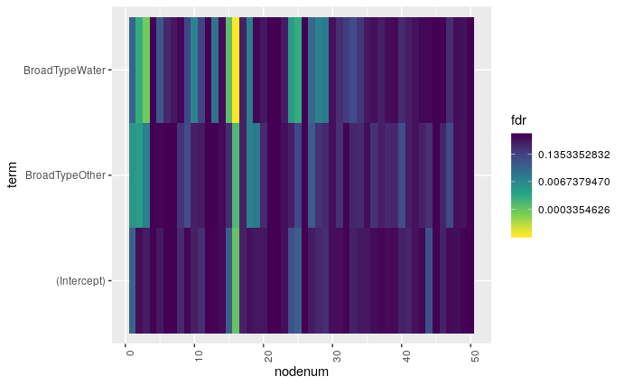

```r
gpsamResults %>% ggplot(aes(x = nodenum, y = term, fill = `fdr`)) + geom_tile() +
  scale_fill_viridis_c(trans = "log", direction = -1) +
  theme(axis.text.x = element_text(angle = 90, hjust = 1))
```

```r
gpsamResults2 <- gpsamResults %>%
  mutate(fdrBinned = cut(fdr, breaks = c(0, 0.001, 0.01, 0.05, 0.2, 0.5, 1),
                                        labels = c("< 0.001", "<0.01", "<0.05", "<0.2", "<0.5", ">0.5"),
                        ordered_result = TRUE))
```

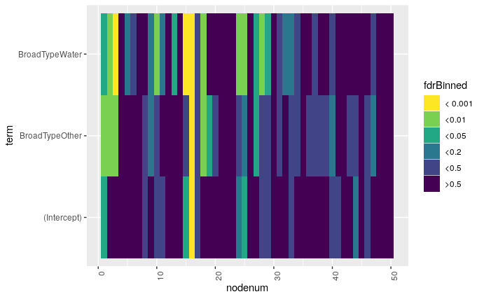

```r
gpsamResults2 %>% ggplot(aes(x = nodenum, y = term, fill = fdrBinned)) + geom_tile() +
  scale_fill_viridis_d(direction = -1) +
  theme(axis.text.x = element_text(angle = 90, hjust = 1))
```

Lots of good hits. Lets look at coefficients too.

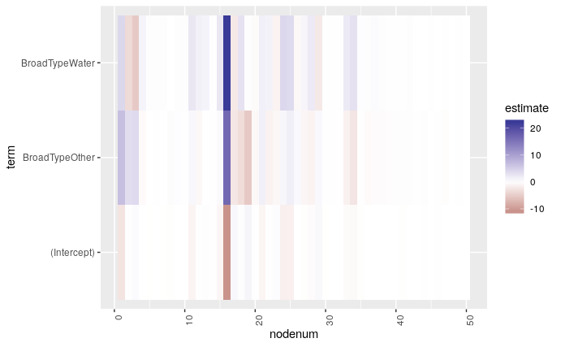

```r
gpsamResults2 %>% ggplot(aes(x = nodenum, y = term, fill = estimate)) + geom_tile() +
  scale_fill_gradient2() +
  theme(axis.text.x = element_text(angle = 90, hjust = 1))
```